# TP FINAL Visualización - sobre TP Grupo 4 Intro a la Programación

Pilar Thill

## Introducción

Este informe se centra en los datos provenientes de la Encuesta sobre Uso del Tiempo realizada en la Ciudad Autónoma de Buenos Aires durante el año 2016. Dicha encuesta fue instrumentada por la Dirección General de Estadísticas y Censos del Gobierno de la Ciudad y sus resultados fueron publicados en formato abierto en 2017. (https://data.buenosaires.gob.ar/dataset/uso-tiempo) Captura información sobre distintas variables de personas residentes en CABA: sexo, edad, nivel de estudios, horas dedicadas al trabajo productivo/pago, horas dedicadas al trabajo doméstico no pago, horas dedicadas a tareas de cuidado, tipo de hogar, ingresos (por quintiles) y estado ocupacional, entre otras. Incluye datos discretos dicotómicos como el sexo y datos continuos como el tiempo para cada tarea. A partir del análisis de los datos arrojados por esta encuesta se podría ponderar la diferencia en el uso del tiempo entre varones y mujeres (sobre todo en la esfera de los cuidados), el índice de la feminización de las tareas de cuidado, etc.

## Exploración de los datos

¿Qué variables tiene? Tiene variables cuantitativas y cualitativas ¿Cuántas observaciones hay? Hay 2336 filas (observaciones) ¿Cuántas variables? 27 variables

Conforme lo señalado en la consigna se seleccionaron las variables de interés y se asignó la info generada a una variable.

Por otro lado, tuve un problema de interpretación del dataset, aún habiendo consultando el informe mencionado y el cuestionario de relevamiento: hay variables con la misma denominación diferenciadas con el “2” que tienen valores disímiles en las observaciones. Ej: tareas_cuidados y tareas_cuidados2. Este punto pude esclarecerlo recién luego de consultar el TP de otro compañero, Gabriel Diner, que calculó promedios y varianzas separando dos bloques de variables.

```r
uso_tiempo_2016|>
  mutate(suma_bloque1= trabajo_pago + trabajo_domestico_no_pago + voluntariados + estudio_educacion + recreacion + aplicaciones + tareas_cuidados + cuidado_personal)|>
  summarise(mean(suma_bloque1), var(suma_bloque1))|>
  knitr::kable()
```

| mean(suma_bloque1) | var(suma_bloque1) |
| --- | --- |
| 26.49756 | 10.41749 |

El promedio de la suma de este primer bloque de variables da 26,5 horas; es decir dos horas y media más que las horas de un día. Eso podría deberse a que es probable que los/as entrevistados/as hayan desarrollado más de una actividad en simultáneo (cocinar y mirar TV por ej.). La varianza es superior a 10, razón por la cual la distancia respecto de la media es grande.

```r
uso_tiempo_2016|>
  mutate(suma_bloque2=trabajo_pago2+trabajo_domestico_no_pago2+voluntariados2+estudio_educacion2+recreacion2+aplicaciones2+tareas_cuidados2+cuidado_personal2)|>
  summarise(mean(suma_bloque2),var(suma_bloque2))|>
  knitr::kable()
```

| mean(suma_bloque2) | var(suma_bloque2) |
| --- | --- |
| 24.04289 | 0.0037525 |

El promedio de la suma de este segundo bloque de variables da 24, razón por la cual es posible que hayan manipulado los valores para que se distribuyan en un día de 24hs. La varianza es 0, razón por la cual la distancia respecto de la media no es significativa.

```r
filter(uso_tiempo_2016_seleccv,edad>=18)|>
  group_by(sexo)|>
  summarise(conteo = n())|>
  knitr::kable()
```

| sexo | conteo |
| --- | --- |
| Mujer | 1316 |
| Varon | 953 |

Con la ejecución de este código la idea fue ver cómo se compone la muestra excluyendo personas entrevistadas menores de 18 años, es decir que excluimos niños, niñas y adolescentes (conf. Ley N° 26.061). Lo que vimos es que hay 1316 observaciones (filas) correspondientes a mujeres y 953 a varones dentro de la variable sexo.

```r
uso_tiempo_2016_seleccv|>
  filter(edad>=18)|>
  group_by(sexo)|>
  summarise(tiempo_max_trabajod_nopago = max(trabajo_domestico_no_pago),tiempo_min_trabajod_nopago = min(trabajo_domestico_no_pago),promedio_trabajod_no_pago = mean(trabajo_domestico_no_pago,na.rm = TRUE))|>
  knitr::kable()
```

| sexo | tiempo_max_trabajod_nopago | tiempo_min_trabajod_nopago | promedio_trabajod_no_pago |
| --- | --- | --- | --- |
| Mujer | 15.7 | 0 | 3.179179 |
| Varon | 12.0 | 0 | 1.863589 |

Este código nos permite observar valores máximos, mínimos y promedios del tiempo (horas) que mujeres y varones de 18 años o más en CABA dedican al trabajo doméstico no remunerado:

1. Existen poco más de tres horas y media de diferencia entre ambas máximas respectivamente (15horas aprox. en el caso de las mujeres y 12 en el caso de los hombres). Es el valor máx. por día laborable.
2. Los valores correspondientes al tiempo mínimo dedicado al trabajo doméstico no pago por varones y mujeres de 18 años o más es de 0, razón por la cual -a priori- pienso que existe una gran dispersión de los datos ponderados para esta variable con relación a su valor promedio.
3. El promedio de horas x día que varones y mujeres mayores de 18 años de CABA dedican al trabajo doméstico no remunerado refleja la desigualdad de género: las mujeres dedican un promedio de 3 horas aprox. y los varones poco menos de dos horas por día (1.8).

```r
uso_tiempo_2016_seleccv|>
  filter(edad>=18)|>
  group_by(sexo)|>
  summarise(desvio = sd(trabajo_domestico_no_pago))|>
  knitr::kable()
```

| sexo | desvio |
| --- | --- |
| Mujer | 2.658873 |
| Varon | 1.987600 |

Efectivamente, se verifica una gran dispersión de los datos sobre el tiempo que varones y mujeres mayores de 18 años en CABA dedican al trabajo doméstico no remunerado: el desvío en el caso de las mujeres es mucho más pronunciado (llega a 2,6 respecto del valor promedio) que en el caso de los varones (1.9).

```r
uso_tiempo_2016_seleccv|>
  filter(edad>=18)|>
  group_by(sexo)|>
  summarise(tiempo_max_tareas_cuidado = max(tareas_cuidados),tiempo_min_tareas_cuidado = min(tareas_cuidados),promedio_tareas_cuidado = mean(tareas_cuidados))|>
  knitr::kable()
```

| sexo | tiempo_max_tareas_cuidado | tiempo_min_tareas_cuidado | promedio_tareas_cuidado |
| --- | --- | --- | --- |
| Mujer | 19.3 | 0 | 1.5465046 |
| Varon | 17.8 | 0 | 0.7275971 |

Este código permitió estimar los valores máximos, mínimos y promedios del tiempo (horas) que varones y mujeres de más de 18 años en CABA dedican a tareas de cuidado por día:

```r
uso_tiempo_2016_seleccv|>
 filter (edad>=18)|>
group_by(sexo)|>
summarise(prom_horas_trabajo_pago = mean(trabajo_pago))|>
  knitr::kable()
```

| sexo | prom_horas_trabajo_pago |
| --- | --- |
| Mujer | 3.556535 |
| Varon | 5.471668 |

Este cuadro muestra cómo los varones de 18 años o más dedican un promedio mayor de horas al trabajo pago que las mujeres: mientras los varones registran un valor promedio de 5 horas y media por día, las mujeres dedican 3 horas al trabajo remunerado.

```r
uso_tiempo_2016_seleccv|>
 filter (edad>=18)|>
group_by(sexo)|>
summarise(valor_prom_recreacion = mean(recreacion))|>
  knitr::kable()
```

| sexo | valor_prom_recreacion |
| --- | --- |
| Mujer | 3.463298 |
| Varon | 3.585624 |

Los valores promedios del tiempo dedicado por hombres y mujeres de 18 años o más en CABA a actividades de recreación es parejo: 3 horas cada une aprox.

### Hipótesis

1 Existe una relación entre las mujeres que dedican 4 horas o más al trabajo doméstico no remunerado y su acceso al trabajo asalariado.

2 Existe una relación entre la cantidad de horas que dedican las mujeres a las tareas de cuidado y el tiempo que le dedican los varones (feminización del cuidado, pobreza de tiempos: la desigual distribución de tareas reproductivas incide en el tiempo que las mujeres de CABA disponen para conseguir empleos, participar en actividades recreativas e incluso procurarse autocuidado).

3 Existe una relación entre el nivel educativo y la cantidad de horas que las mujeres dedican al trabajo remunerado.

#### Prueba de hipótesis

**1.Existe una relación entre las mujeres que dedican 4hs o más al trabajo doméstico no remunerado y su acceso al trabajo asalariado**

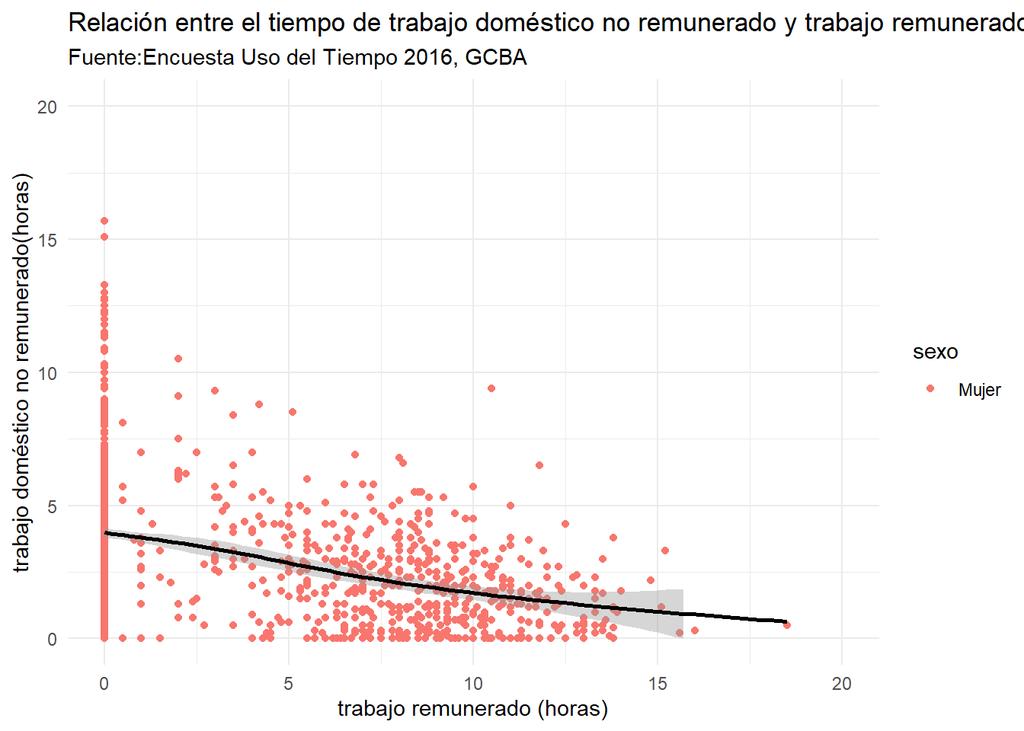

```r
uso_tiempo_2016|>
  filter (edad>=18, sexo=="Mujer")|>
  ggplot(aes(trabajo_pago,trabajo_domestico_no_pago))+
  geom_point(aes(colour=sexo, SE=FALSE))+
  geom_smooth(colour="black", span=1)+
  scale_x_continuous(limits=c(0,20))+
  scale_y_continuous(limits=c(0,20))+
  labs(title="Relación entre el tiempo de trabajo doméstico no remunerado y trabajo remunerado de mujeres mayores de 18 años residentes en CABA", subtitle="Fuente:Encuesta Uso del Tiempo 2016, GCBA", x="trabajo remunerado (horas)", y="trabajo doméstico no remunerado(horas)")+
  theme_minimal()
```

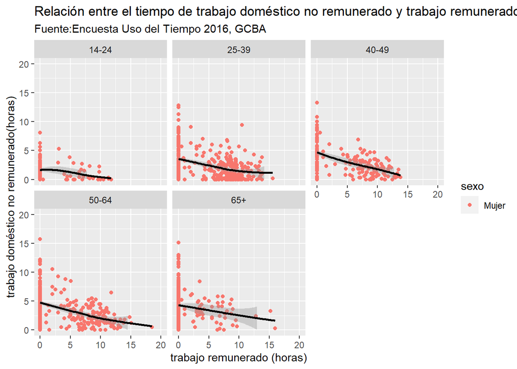

```r
uso_tiempo_2016|>
  filter (edad>=18, sexo=="Mujer")|>
  ggplot(aes(trabajo_pago,trabajo_domestico_no_pago))+
  geom_point(aes(colour=sexo, SE=FALSE))+
  geom_smooth(colour="black", span=1)+
  scale_x_continuous(limits=c(0,20))+
  scale_y_continuous(limits=c(0,20))+
  labs(title="Relación entre el tiempo de trabajo doméstico no remunerado y trabajo remunerado por rango etario de mujeres mayores de 18 años residentes en CABA", subtitle="Fuente:Encuesta Uso del Tiempo 2016, GCBA", x="trabajo remunerado (horas)", y="trabajo doméstico no remunerado(horas)")+
  facet_wrap(~rango_etario)
```

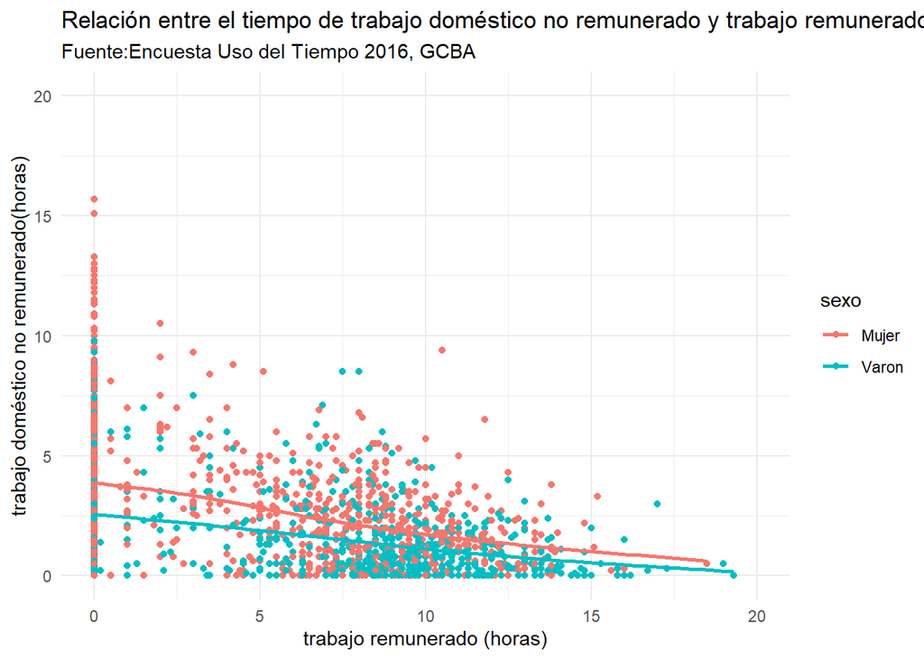

```r
uso_tiempo_2016 |>
ggplot(aes(trabajo_pago, trabajo_domestico_no_pago))+
  geom_point(aes(color=sexo))+
  geom_smooth(aes(color=sexo), se=FALSE)+
  scale_x_continuous(limits=c(0,20))+
  scale_y_continuous(limits=c(0,20))+
  labs(title="Relación entre el tiempo de trabajo doméstico no remunerado y trabajo remunerado de varones y mujeres mayores de 18 años residentes en CABA", subtitle="Fuente:Encuesta Uso del Tiempo 2016, GCBA", x="trabajo remunerado (horas)", y="trabajo doméstico no remunerado(horas)")+
  theme_minimal()
```

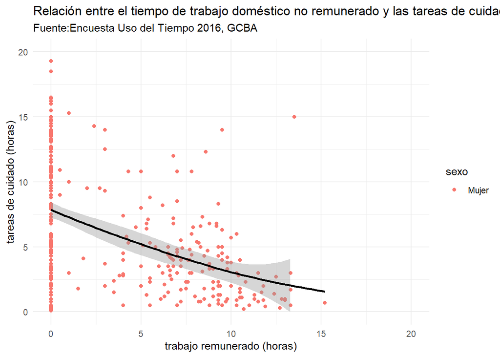

```r
uso_tiempo_2016|>
  filter (edad>=18, tareas_cuidados>0, sexo=="Mujer")|>
  ggplot(aes(trabajo_pago,tareas_cuidados))+
  geom_point(aes(colour=sexo, SE=FALSE))+
  geom_smooth(colour="black", span=1)+
  scale_x_continuous(limits=c(0,20))+
  scale_y_continuous(limits=c(0,20))+
  labs(title="Relación entre el tiempo de trabajo doméstico no remunerado y las tareas de cuidado de mujeres mayores de 18 años residentes en CABA", subtitle="Fuente:Encuesta Uso del Tiempo 2016, GCBA", x="trabajo remunerado (horas)", y="tareas de cuidado (horas)")+
  theme_minimal()
```

A priori se observan muchos casos (puntos) en el “eje y” de mujeres que dedican horas a tareas de cuidado que no trabajan de forma de remunerada. La regresión pareciera mostrar que a medida que aumenta la cantidad de horas que las mujeres mayores de 18 años dedican a tareas de cuidado decrece la cantidad de horas que están en condiciones de dedicar al trabajo asalariado.

```r
mujeres_18<-uso_tiempo_2016|>
  filter(sexo=="Mujer", edad>=18)
```

Asigné una nueva variable para trabajar únicamente con mujeres de 18 años o más, es decir que me interesa ver qué pasa con aquellas que no son niñas.

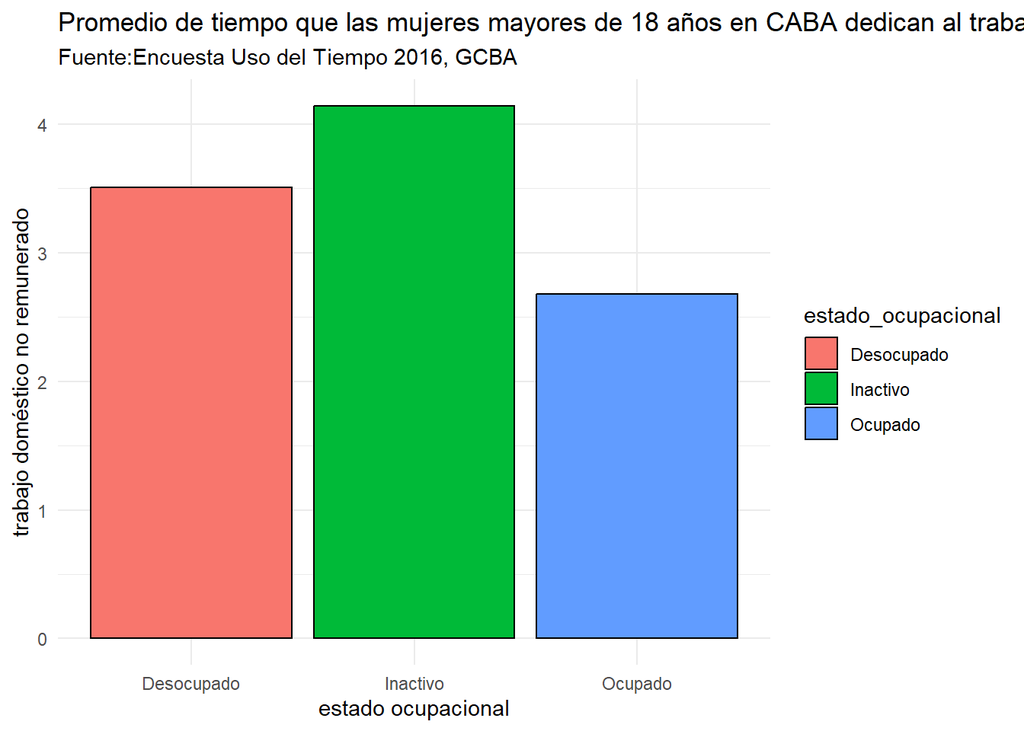

```r
mujeres_18|>
  group_by(estado_ocupacional)|>
  summarise(media_trabajo_domestico_no_pago=mean(trabajo_domestico_no_pago,na.rm = TRUE))|>
  ggplot(aes(estado_ocupacional,media_trabajo_domestico_no_pago,fill=estado_ocupacional))+
  geom_col(colour="black")+
  labs (title="Promedio de tiempo que las mujeres mayores de 18 años en CABA dedican al trabajo doméstico no remunerado por estado ocupacional", subtitle="Fuente:Encuesta Uso del Tiempo 2016, GCBA", x="estado ocupacional", y="trabajo doméstico no remunerado")+
  theme_minimal()
```

Este gráfico muestra que las mujeres residentes en CABA (de 18 años o más) que dedican un mayor promedio de horas al trabajo doméstico no remunerado son aquellas que están desocupadas o inactivas.

Veamos ahora cuál es la frecuencia de casos por rango etario y estado ocupacional.

```r
uso_tiempo_2016|>
  filter (sexo=="Mujer", edad>=18)|>
  group_by(rango_etario)|>
  summarise(frequencia = n())|>
  knitr::kable()
```

| rango_etario | frequencia |
| --- | --- |
| 14-24 | 119 |
| 25-39 | 362 |
| 40-49 | 187 |
| 50-64 | 295 |
| 65+ | 353 |

Este código muestra que las mayores concentraciones de casos se registran en las siguientes franjas etarias: 25 a 39 años, con 362 casos; 65 o más con 353 casos y 50 a 64 años, con 295 casos. Esto indica que en la muestra hay una importante cantidad de mujeres de 60 años o más que posiblemente estén jubiladas, es decir consideradas como inactivas, pero que dedican horas al trabajo doméstico no remunerado en el ámbito de sus hogares.Y si a eso sumanos los casos de las mujeres que se ubican en la franja de 14 a 24 años (119 casos), sobre todo aquellas en edad escolar, queda en evidencia la inadecuación de la categoría “inactividad” para mujeres que no tienen un trabajo pago pero que realizan tareas domésticas no remuneradas.

```r
uso_tiempo_2016|>
  filter (sexo=="Mujer", edad>=18)|>
  group_by(estado_ocupacional)|>
  summarise(frequencia = n())|>
  knitr::kable()
```

| estado_ocupacional | frequencia |
| --- | --- |
| Desocupado | 61 |
| Inactivo | 416 |
| Ocupado | 839 |

Este código muestra que las mujeres consideradas inactivas representan casi la mitad de la cifra correspondiente a mujeres ocupadas.

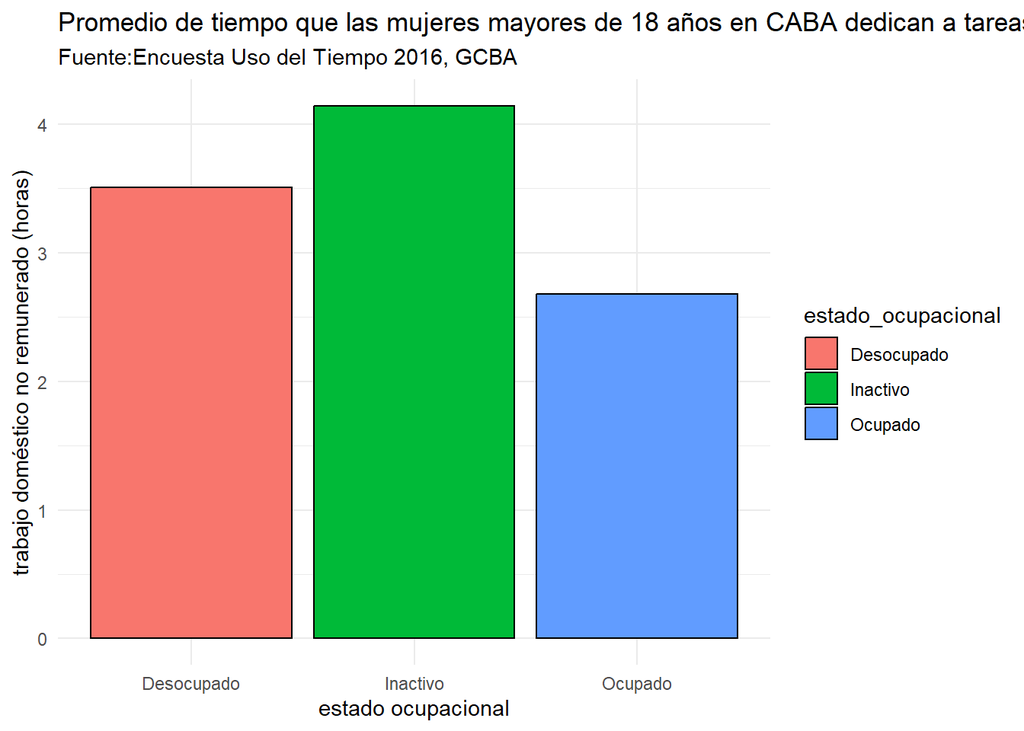

```r
mujeres_18|>
  group_by(estado_ocupacional)|>
  summarise(media_tareas_cuidados=mean(trabajo_domestico_no_pago))|>
  ggplot(aes(estado_ocupacional,media_tareas_cuidados,fill=estado_ocupacional))+
  geom_col(colour="black")+
  labs (title="Promedio de tiempo que las mujeres mayores de 18 años en CABA dedican a tareas de cuidado por estado ocupacional", subtitle="Fuente:Encuesta Uso del Tiempo 2016, GCBA", x="estado ocupacional", y="trabajo doméstico no remunerado (horas)")+
  theme_minimal()
```

**¿Existe una relación entre la cantidad de horas que dedican las mujeres a las tareas de cuidado y el tiempo que le dedican los varones?**

(feminización del cuidado, pobreza de tiempos: la desigual distribución de tareas reproductivas incide en el tiempo que las mujeres de CABA disponen para conseguir empleos, participar en actividades recreativas,etc)

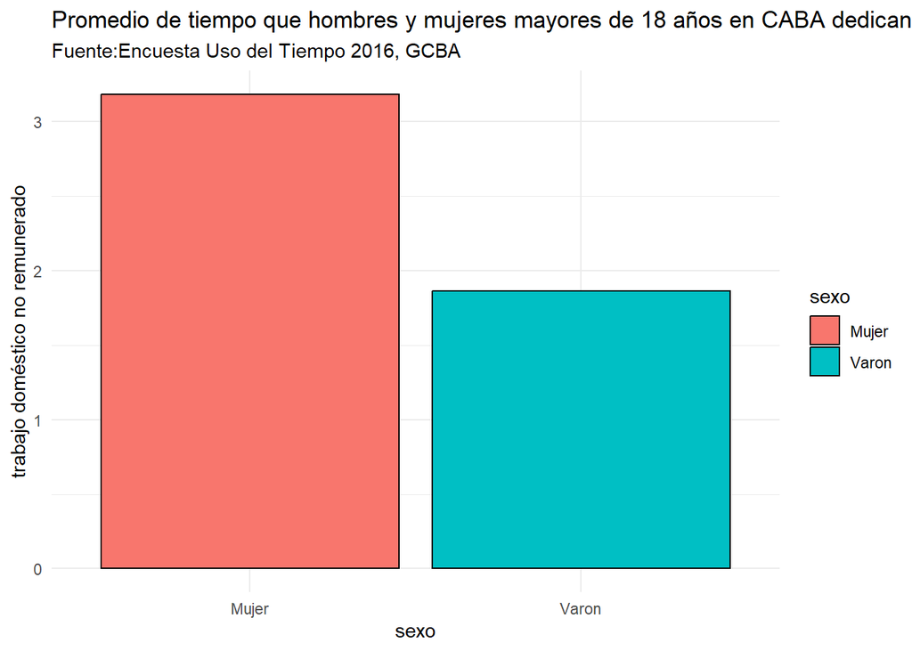

```r
uso_tiempo_2016|>
  filter(edad>=18)|>
  group_by(sexo)|>
  summarise(media_trabajo_domestico_no_pago=mean(trabajo_domestico_no_pago))|>
  ggplot(mapping = aes(sexo,media_trabajo_domestico_no_pago,fill=sexo))+
geom_col(colour="black")+
  labs (title="Promedio de tiempo que hombres y mujeres mayores de 18 años en CABA dedican al trabajo doméstico no remunerado por estado ocupacional", subtitle="Fuente:Encuesta Uso del Tiempo 2016, GCBA", x="sexo", y="trabajo doméstico no remunerado")+
  theme_minimal()
```

Este gráfico muestra que la media de horas que las mujeres de 18 años o más residentes en Caba es notablemente superior a la media que dedican los hombres a partir de esa misma edad.

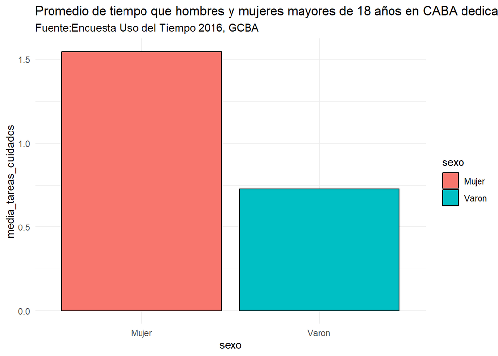

```r
uso_tiempo_2016|>
  filter(edad>=18)|>
  group_by(sexo)|>
  summarise(media_tareas_cuidados=mean(tareas_cuidados,na.rm = TRUE))|>
  ggplot(mapping = aes(sexo,media_tareas_cuidados,fill=sexo))+
geom_col(colour= "black")+
  labs (title="Promedio de tiempo que hombres y mujeres mayores de 18 años en CABA dedican a tareas de cuidados", subtitle="Fuente:Encuesta Uso del Tiempo 2016, GCBA")+
  theme_minimal()
```

Este gráfico muestra que la media de horas que las mujeres de 18 años o más residentes en CABA dedican a tareas de cuidados es superior a la media de horas que dedican los varones a partir de la misma edad por día.

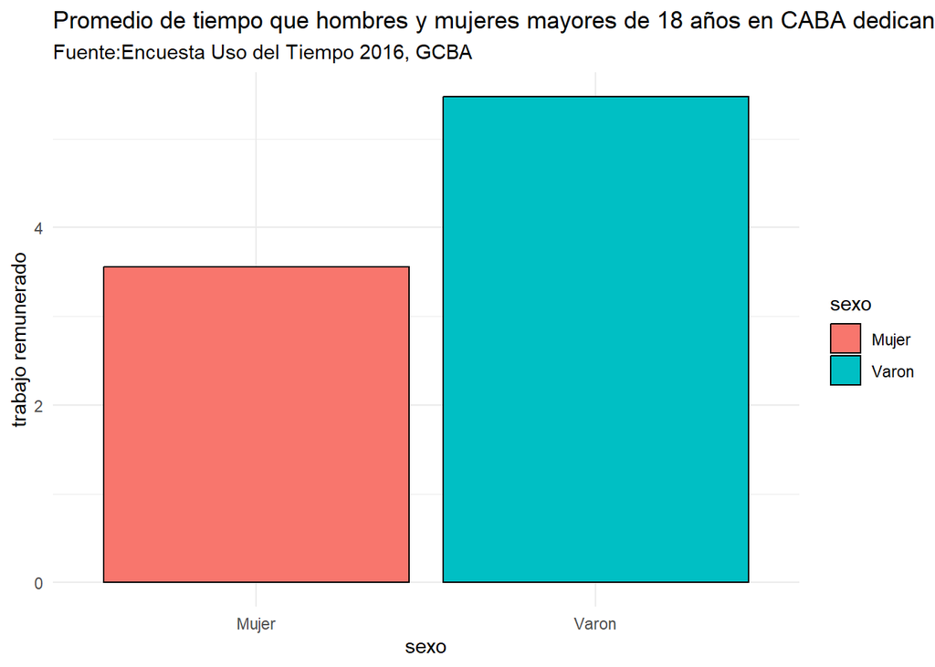

```r
uso_tiempo_2016|>
  filter(edad>=18)|>
  group_by(sexo)|>
  summarise(media_trabajo_pago=mean(trabajo_pago,na.rm = TRUE))|>
  ggplot(mapping = aes(sexo,media_trabajo_pago,fill=sexo))+
geom_col(colour="black")+
  labs (title="Promedio de tiempo que hombres y mujeres mayores de 18 años en CABA dedican al trabajo remunerado", subtitle="Fuente:Encuesta Uso del Tiempo 2016, GCBA", y="trabajo remunerado")+
  theme_minimal()
```

Con este gráfico se observa claramente cómo los varones mayores de 18 años residentes en CABA registran un promedio superior de horas dedicadas al trabajo pago que el promedio de las mujeres.

**¿Existe una relación entre el nivel educativo y la cantidad de horas que las mujeres dedican al trabajo remunerado?**

```r
media_trabajo_pago_por_nivel_educ<-uso_tiempo_2016|>
  filter(edad>=18,sexo=="Mujer")|>
  group_by(nivel_educativo)|>
  summarise(media_trabajo_pago=mean(trabajo_pago,na.rm = TRUE))
```

Creé una nueva variable que retrata el promedio de las horas de trabajo pago para las mujeres de 18 años o más residentes en CABA según su nivel educativo.

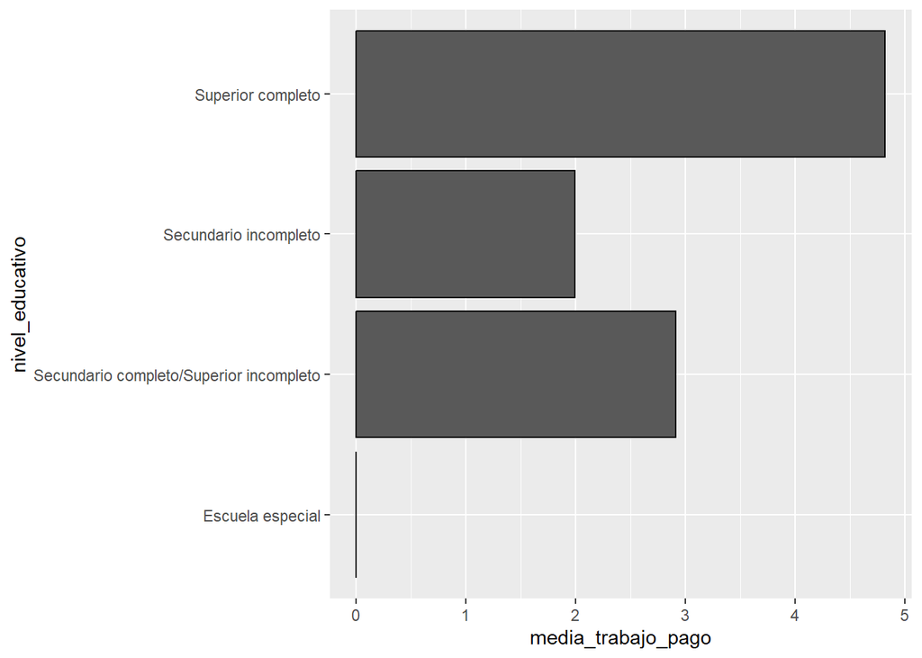

```r
media_trabajo_pago_por_nivel_educ|>
  arrange(nivel_educativo)|>
  ggplot(mapping = aes(media_trabajo_pago, nivel_educativo))+
  geom_col(color="black")
```

Este gráfico confirma la hipótesis planteada: a mayor nivel educativo, mayor es el promedio de horas que las mujeres dedican al trabajo pago.Las mujeres con algún tipo de discapacidad escolarizadas en escuelas especiales no registran horas dedicadas al trabajo pago.

##### Conclusiones

En el caso de la primera hipótesis, entiendo que la formulé de manera errónea,con parámetros demasiado específicos (debería haber sido la relación entre la cantidad de horas que las mujeres destinan al trabajo doméstico no pago y la cantidad de horas que dedican al trabajo pago). No obstante, surgieron datos interesantes: las mujeres desocupadas e inactivas de 18 años o más residentes en CABA dedican un promedio mayor de tiempo al trabajo doméstico no pago que aquellas que están ocupadas.Es decir que el estado ocupacional incide en el tiempo que las mujeres dedican al trabajo reproductivo(tareas de cuidado+trabajo doméstico no pago).En el caso particular de las mujeres categorizadas como inactivas paradojalmente son las que más tiempo dedican al trabajo doméstico no pago. Con relación a la segunda hipótesis, también entiendo que estuvo mal redactada porque debería haberme referido a las desigualdades de género que fundamentan los resultados del análisis hecho. Lo que apareció claro es que las tareas de cuidado están feminizadas: es mayor el promedio de horas que mujeres dedican a tareas de cuidados y trabajo doméstico no pago que el promedio que dedican los varones.Asimismo,se registró un mayor promedio de horas dedicadas al trabajo pago en el caso de los varones. En el caso de tercera hipótesis, resultó confirmada: a mayor nivel educativo, mayor es el promedio de horas que las mujeres dedican al trabajo remunerado.